# Table of content

- Time Series Model
  - Libraries
  - Cryptocurrency data
    - Close prices plot
  - Identify and Check
    - Correlogram
    - Differences
    - Analisys
  - Select the best
  - Summary of the best
    - Residuals plots
  - Forecast

## Libraries

```python
import pandas as pd
import numpy as np
from function_consulting import * # function own

import plotnine as p9 # ggplot
import matplotlib.pyplot as plt

from statsmodels.tsa.arima_model import ARIMA
import statsmodels.api as sm

import warnings
import sqlalchemy as db

# variables y funciones globales
plt.rcParams.update({'figure.figsize':(20,10), 'figure.dpi':100})
warnings.filterwarnings('ignore')
plt.style.use('ggplot')
color_line = '#D302AA'
```

## Cryptocurrency data

I'll be going work with the BTC-USD time serie.

```python
data_btc = connection_db_sql(database = 'crypto_series',consult_sql_server = "SELECT * FROM data_crypto WHERE symbol = 'BTC-USD'")
data_btc_filter = data_btc.loc['2021']
data_btc_filter.tail(10)
```

| Date | Open | High | Low | Close | Volume | Dividends | Stock Splits | symbol |
| --- | --- | --- | --- | --- | --- | --- | --- | --- |
| 2021-11-05 | 61460.078125 | 62541.468750 | 60844.609375 | 61125.675781 | 30605102446 | 0 | 0 | BTC-USD |
| 2021-11-06 | 61068.875000 | 61590.683594 | 60163.781250 | 61527.480469 | 29094934221 | 0 | 0 | BTC-USD |
| 2021-11-07 | 61554.921875 | 63326.988281 | 61432.488281 | 63326.988281 | 24726754302 | 0 | 0 | BTC-USD |
| 2021-11-08 | 63344.066406 | 67673.742188 | 63344.066406 | 67566.828125 | 41125608330 | 0 | 0 | BTC-USD |
| 2021-11-09 | 67549.734375 | 68530.335938 | 66382.062500 | 66971.828125 | 42357991721 | 0 | 0 | BTC-USD |
| 2021-11-10 | 66953.335938 | 68789.625000 | 63208.113281 | 64995.230469 | 48730828378 | 0 | 0 | BTC-USD |
| 2021-11-11 | 64978.890625 | 65579.015625 | 64180.488281 | 64949.960938 | 35880633236 | 0 | 0 | BTC-USD |
| 2021-11-12 | 64863.980469 | 65460.816406 | 62333.914062 | 64155.941406 | 36084893887 | 0 | 0 | BTC-USD |
| 2021-11-13 | 64158.121094 | 64915.675781 | 63303.734375 | 64469.527344 | 30474228777 | 0 | 0 | BTC-USD |
| 2021-11-14 | 64455.371094 | 65495.179688 | 63647.808594 | 65466.839844 | 25122092191 | 0 | 0 | BTC-USD |

Source: https://finance.yahoo.com/cryptocurrencies/

### Close prices plot

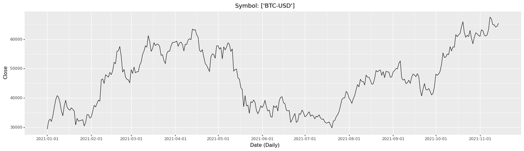

```python
(   p9.ggplot(data_btc_filter.reset_index(), p9.aes('Date', 'Close')) +
    p9.geom_line() +
    p9.theme(figure_size=(20, 5)) +
    p9.labs(title = f'Symbol: {np.unique(data_btc_filter.symbol)}') +
    p9.xlab('Date (Daily)'))
```

In the plot we to watch of the time series, the BTC has a growing behavior, It's possible it's behavior is not stationary.

## Identify and Check

```python
test_dickey_fuller(data_btc_filter, 'Close')
```

```
stats:-1.624159078138683
p-value: 0.47054953445338743
```

The p-value is the greather than 0.05, so We check what this series it's not stacionary.

### Correlogram

Now, We can visualaze the correlogram, in both plot there are not information for make of ARIMA model, so, It's necesary to make differeciate the serie

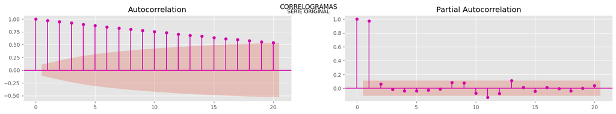

```python
graf_correlograma(data_btc_filter, 'Close', color_line, 'SERIE ORIGINAL')
```

To begin, I work with the first and second differences.

### Differences

```python
data_btc_filter['diff1'] =  data_btc_filter.Close.diff()
data_btc_filter['diff2'] = data_btc_filter['diff1'].diff()
data_btc_filter.head(10)
```

| Date | Open | High | Low | Close | Volume | Dividends | Stock Splits | symbol | diff1 | diff2 |
| --- | --- | --- | --- | --- | --- | --- | --- | --- | --- | --- |
| 2021-01-01 | 28994.009766 | 29600.626953 | 28803.585938 | 29374.152344 | 40730301359 | 0 | 0 | BTC-USD | NaN | NaN |
| 2021-01-02 | 29376.455078 | 33155.117188 | 29091.181641 | 32127.267578 | 67865420765 | 0 | 0 | BTC-USD | 2753.115234 | NaN |
| 2021-01-03 | 32129.408203 | 34608.558594 | 32052.316406 | 32782.023438 | 78665235202 | 0 | 0 | BTC-USD | 654.755859 | -2098.359375 |
| 2021-01-04 | 32810.949219 | 33440.218750 | 28722.755859 | 31971.914062 | 81163475344 | 0 | 0 | BTC-USD | -810.109375 | -1464.865234 |
| 2021-01-05 | 31977.041016 | 34437.589844 | 30221.187500 | 33992.429688 | 67547324782 | 0 | 0 | BTC-USD | 2020.515625 | 2830.625000 |
| 2021-01-06 | 34013.613281 | 36879.699219 | 33514.035156 | 36824.363281 | 75289433811 | 0 | 0 | BTC-USD | 2831.933594 | 811.417969 |
| 2021-01-07 | 36833.875000 | 40180.367188 | 36491.191406 | 39371.042969 | 84762141031 | 0 | 0 | BTC-USD | 2546.679688 | -285.253906 |
| 2021-01-08 | 39381.765625 | 41946.738281 | 36838.636719 | 40797.609375 | 88107519480 | 0 | 0 | BTC-USD | 1426.566406 | -1120.113281 |
| 2021-01-09 | 40788.640625 | 41436.351562 | 38980.875000 | 40254.546875 | 61984162837 | 0 | 0 | BTC-USD | -543.062500 | -1969.628906 |
| 2021-01-10 | 40254.218750 | 41420.191406 | 35984.628906 | 38356.441406 | 79980747690 | 0 | 0 | BTC-USD | -1898.105469 | -1355.042969 |

### Analisys

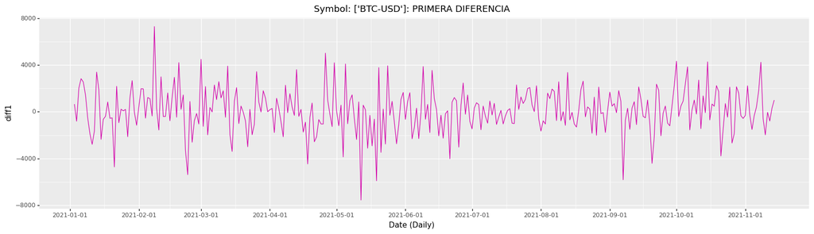

```python
graf_diff(data_btc_filter, 'diff1', color_line, 'PRIMERA DIFERENCIA')
```

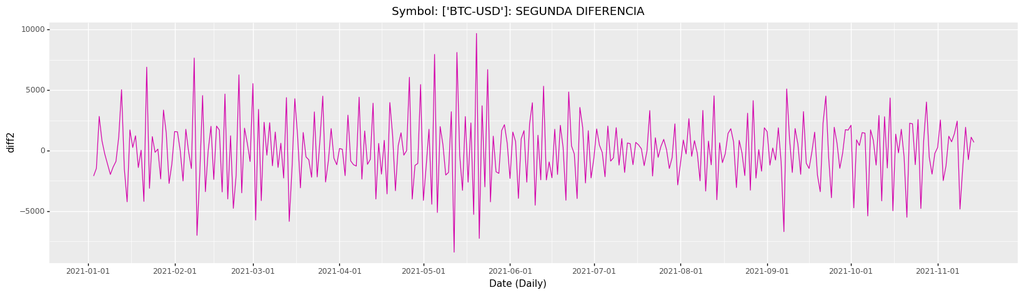

```python
graf_diff(data_btc_filter, 'diff2', color_line, 'SEGUNDA DIFERENCIA')
```

### a. result - first difference

```python
test_dickey_fuller(data_btc_filter, 'diff1')
```

```
stats:-18.71304024963417
p-value: 2.0342937366467405e-30
```

### b. result - second difference

```python
test_dickey_fuller(data_btc_filter, 'diff2')
```

```
stats:-8.129335488841157
p-value: 1.1010389325186145e-12
```

in both case, we check of the stationarity

## Select the best

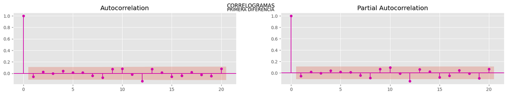

```python
graf_correlograma(data_btc_filter, 'diff1', color_line, 'PRIMERA DIFERENCIA')
```

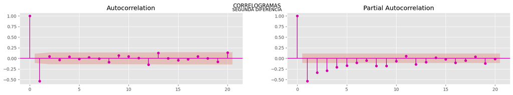

```python
graf_correlograma(data_btc_filter, 'diff2', color_line, 'SEGUNDA DIFERENCIA')
```

In this case, there are significant lags in autocorrelation and partial autocorrelation, it can be **ARIMA (2,2,3)**, so I combined the value of the differences between p and q, with maximum value p = 2, q = 3 and maximum of differentiating in the series equal 2.

```python
the_best_models(2,2,3, data_btc_filter['Close'])
```

| model | AIC | BIC |
| --- | --- | --- |
| ARIMA(2,2,3) | 5651.13 | 5677.38 |
| ARIMA(0,2,1) | 5651.98 | 5663.23 |
| ARIMA(1,0,0) | 5684.02 | 5695.29 |
| ARIMA(2,2,0) | 5739.00 | 5753.99 |
| ARIMA(1,2,0) | 5774.35 | 5785.59 |
| ARIMA(0,0,1) | 6380.14 | 6391.41 |

## Summary of the best

```python
model_1 = ARIMA(data_btc_filter.Close.values, order=(2, 2, 3))
model_1_fit1 = model_1.fit(disp=0)
print(model_1_fit1.summary())
```

```
                             ARIMA Model Results
==============================================================================
Dep. Variable:                   D2.y   No. Observations:                  314
Model:                 ARIMA(2, 2, 3)   Log Likelihood               -2818.566
Method:                       css-mle   S.D. of innovations           1885.460
Date:                Mon, 15 Nov 2021   AIC                           5651.133
Time:                        22:25:07   BIC                           5677.379
Sample:                             2   HQIC                          5661.620

==============================================================================
                 coef    std err          z      P>|z|      [0.025      0.975]
------------------------------------------------------------------------------
const          0.2828      1.212      0.233      0.815      -2.092       2.658
ar.L1.D2.y    -0.1877      0.029     -6.501      0.000      -0.244      -0.131
ar.L2.D2.y    -0.9202      0.025    -37.241      0.000      -0.969      -0.872
ma.L1.D2.y    -0.8131      0.018    -46.142      0.000      -0.848      -0.779
ma.L2.D2.y     0.8132      0.019     42.300      0.000       0.776       0.851
ma.L3.D2.y    -0.9999      0.022    -44.876      0.000      -1.044      -0.956
                                    Roots
=============================================================================
                  Real          Imaginary           Modulus         Frequency
-----------------------------------------------------------------------------
AR.1           -0.1020           -1.0374j            1.0424           -0.2656
AR.2           -0.1020           +1.0374j            1.0424            0.2656
MA.1            1.0001           -0.0000j            1.0001           -0.0000
MA.2           -0.0934           -0.9956j            1.0000           -0.2649
MA.3           -0.0934           +0.9956j            1.0000            0.2649
-----------------------------------------------------------------------------
```

```python
sm.stats.acorr_ljungbox(model_1_fit1.resid, lags=[10], return_df=True)
```

|  | lb_stat | lb_pvalue |
| --- | --- | --- |
| 10 | 5.715742 | 0.838553 |

### residuals plots

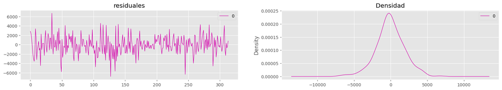

```python
residuales = pd.DataFrame(model_1_fit1.resid)
fig, ax = plt.subplots(1,2)
residuales.plot(title = 'residuales', ax = ax[0], color =  color_line, lw = .9)
residuales.plot(kind = 'kde', title = 'Densidad', ax = ax[1], color = color_line, lw =.9)
plt.show()
```

## Forecast

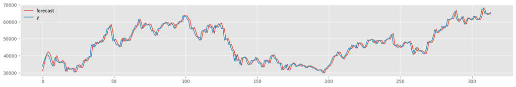

```python
model_1_fit1.plot_predict()
plt.show()
```

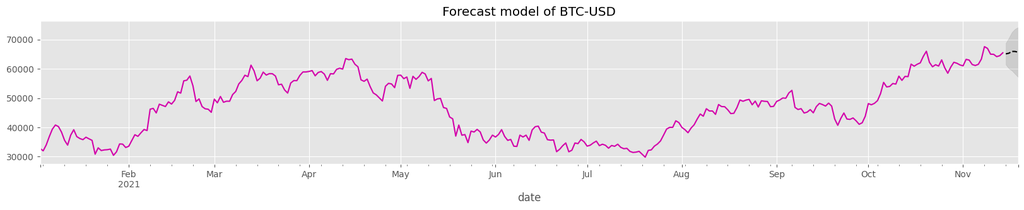

```python
n = 5 # Max 5 days
fc, se, conf = model_1_fit1.forecast(n, alpha=0.05)
dates = pd.date_range(max(data_btc_filter.index) + timedelta(days = 1), periods=n)

forecast_data = pd.DataFrame({'date':dates, 'fc':fc, 'se':se, 'lower_series':conf[:, 0], 'upper_series': conf[:, 1]})
forecast_data.set_index('date', inplace=True)

fig, ax = plt.subplots()
data_btc_filter.Close.plot(ax=ax, color = color_line)

# Construct the forecasts
forecast_data.fc.plot(ax=ax, style='k--')
ax.fill_between(forecast_data.index, forecast_data['lower_series'], forecast_data['upper_series'], color='k', alpha=0.1)
plt.title('Forecast model of BTC-USD')
plt.show()
```

```python
pd.DataFrame(forecast_data)

# Max 5 days
```

| date | fc | se | lower_series | upper_series |
| --- | --- | --- | --- | --- |
| 2021-11-15 | 65092.099290 | 1885.459671 | 61396.666241 | 68787.532339 |
| 2021-11-16 | 65324.823847 | 2665.311252 | 60100.909785 | 70548.737909 |
| 2021-11-17 | 65937.794685 | 3353.259304 | 59365.527218 | 72510.062152 |
| 2021-11-18 | 65920.977217 | 3908.692169 | 58260.081340 | 73581.873094 |
| 2021-11-19 | 65673.078149 | 4335.076308 | 57176.484716 | 74169.671582 |

```python
# connection
current_forecast(forecast_data)
```

# Bibliography

[Time series analysis with applications in r Cryer and Chan](https://mybiostats.files.wordpress.com/2015/03/time-series-analysis-with-applications-in-r-cryer-and-chan.pdf)